# conversao_migracao

Mori, Danilo Pereira

23 de abril de 2018

## Objetivo

Comparar os dois métodos de conversão de parâmetro de migração entre um modelo neutro de campo médio (Etienne 2005) e um modelo neutro de espaço explícito (Rosindell et al. 2008) a partir de deduções da eq 1 apresentada por Chisholm & Lichstein (2009). O primeiro método é desenvolvido pelos autores anteriores e trata-se de uma aproximação (eq2 Chisholm & Lichstein 2009); o segundo método foi deduzido a partir da eq 1 e aproveitou das particularidades de nossas simulações para deduzir uma equação. Ambos métodos relacionam a probabilidade de um indivíduo de fora da comunidade colonizar uma unidade de habitat na comunidade local por evento de morte (‘m’) com a distância média de dispersão dos indivíduos na paisagem (‘d’).

O modelo neutro espacialmente explícito tem as seguintes características: i) utilizamos apenas áreas amostradas contíguas que aproximamos como quadrados; ii) a distribuição de probabilidade subjacente a função de dispersão é Laplace e parametrizamos a partir do desvio-padrão; iii) a área foi escrita em função de J e DA, número de indivíduos e densidade(ind/ha) observada na amostra, respectivamente.

### Contexto

Chisholm & Lichstein (2009) (doravante C&L09) estabeleceram uma relação entre *m* e *A* (a área da comunidade local):

> When an individual at location (x, y) in the local community dies, the replacement individual may, by virtue of the random dispersal and recruitment processes, be from within the local community (i.e., within the quadrat) or from outside the local community (i.e., from outside the quadrat). Define m x,y as the probability that the replacement individual at location (x, y) is drawn from outside the local community. This parameter will be highest for individuals on the edges of the quadrat and smallest for individuals at the centre of the quadrat, where m x,y » 0 for large A. We define m as the average value of m x,y across the whole of the local community as follows:

$$eq.0: m = \frac{1}{A} \int \int_A m_{x,y} dxdy$$

Essa equação é válida para o processo de dispersão em ambientes homogêneos, ou seja, sem fragmentação. A maneira que simulamos a dispersão em paisagens fragmentadas é diferente em uma simulação coalescente: uma vez que sorteamos um progenitor e este estaria presente em uma unidade de não habitat, o sorteio é refeito até que o progenitor esteja em uma unidade de habitat. Uma vez que o sorteio é refeito este pode cair novamente dentro da área da comunidade local, uma equação que descreve exatamente a probabilidade de um indivíduo da comunidade ser substituido por um indivíduo de fora da comunidade em uma paisagem fragmentada dependeria de explicitamente considerar a configuração espacial. Uma aproximação do efeito da fragmentação na simulação é considerar que a chance da dispersão ser oriunda de uma área de cobertura vegetal, assim, podemos corrigir m pela porcentagem de cobertura vegetal na paisagem:

$$eq.0': m' = \frac{mp}{1 - (1-p)m}$$

Onde *p* é a porcentagem de cobertura vegetal na paisagem. É necessário corrigir o valor de m quando partimos de parâmetros da simulação coalescente em paisagens fragmentadas, contudo não é correto corrigir ‘m’ obtidos pelo ajuste do modelo neutro de campo médio.

### Método C&L09

A aproximação deduzida por C&L09 é $m = \frac{Pd}{\pi A}$, onde P e A são o perímetro e área do plot, respectivamente. Considerando o plot quadrado e a distribuição de Laplace podemos reescrever essa aproximação como:

$$eq.1: m = sd \frac{4}{L \pi \sqrt{2} }$$

Onde $P = 4 L$, $A = L^2$ e $L= 100 \sqrt{J/DA}$ metros

### Método Coutinho apud C&L09

Coutinho parte da eq.0 e aproveitando as características da simulação coalescente que utilizamos: a) utiliza apenas plot quadrados; b) a dispersão não é radial, ao invés, é descrita como o resultado do sorteio independente em eixos ortogonais. Assim, podemos escrever a eq.0 como:

$$eq.0-C.a: m = \left(\frac{1}{L} \int\limits_{-L/2}^{L/2} m_{x}(x)\mathrm{d}x \right)^2$$

$$eq.0-C.b: m_{x} = 1 - \int\limits_{-L/2}^{L/2} K(x-y) \mathrm{d}y$$

K é a função de dispersão. Podemos reescrevemos considerando a distribuição de probabilidade de Laplace como:

Para escrever a equação em função do desvio-padrão (eq 2b) utilizamos o ramo principal da função W de Lambert ($W_0$).

### Comparação dos métodos

Para comparar os métodos vou utilizar os parâmetros ajustados (modelo de campor médio, por verossimilhança) à SADs amostradas na Mata Atlântica e aqueles estimados por um modelo neutro espacialmente explícito. Todos os vetores de abundância foram observados em amostras com pelo menos 1 ha. As SADs observadas foram ajustado ao modelo de campo médio e obtemos m; no modelo de espaço explícito informamos *a priori* qual o desvio padrão da função de dispersão. Então vamos utilizar as equações 1a e 2a para calcular m a partir dos desvio-padrões informados *a prior*, considerando o m’ corrigido. As equações 1b e 2b irão converter m em desvio padrão. Para isso vou criar uma função que contêm as equações e a definição de $\theta$ de Hubbell (2001):

```r
f_conv.par <- function(modelo, par., par.aux) {
    # parametros que seram convertidos
    theta <- par.[[1]]
    m <- par.[[2]]
    sd_k <- par.[[3]]
    U <- par.[[4]]
    # parametros auxiliares a conversao
    p <- par.aux[[1]]
    J <- par.aux[[2]]
    DA <- par.aux[[3]]
    L <- 100 * sqrt(J/DA)
    # conversoes EI -> EE
    if (modelo == "campo_medio") {
        U_ <- theta/(2 * 500 * p * DA)  # Hubbell 2001
        sd_k.CL <- m * L * pi * sqrt(2)/4  # eq 1b
        sd_K.CaCL <- sqrt(2) * L/(m * lambertW0(-exp(-1/m)/m) + 1)  # eq 2b
        df_ <- data.frame(par.value = c(U_, sd_k.CL, sd_K.CaCL), par.class = c("U",
            "sd_k", "sd_k"), par.method = c("H01", "CL", "CaCL"))
        return(df_)
    } else {
        # EE -> EI
        theta_ <- 2 * 500 * p * DA * U  # Hubbell 2001
        m_CL <- 4 * sd_k/(sqrt(2) * L * pi)  # eq 1a
        m_CaCL <- sd_k * (1 - exp(-sqrt(2) * L/sd_k))/(sqrt(2) * L/sd_k)  # eq 2a
        df_ <- data.frame(par.value = c(theta_, m_CL, m_CaCL), par.class = c("theta",
            "m", "m"), par.method = c("H01", "CL", "CaCL"))
        return(df_)
    }
}

# aplicando a formula
df_par.conv <- ddply(df_resultados, c("SiteCode", "kernel_percentil"), function(X) f_conv.par(modelo = X[,
    "kernel_percentil"], par. = as.list(X[, c("theta", "m", "sd_k", "U")]),
    par.aux = as.list(X[, c("p", "J", "DA")])))
```

Esperamos que os métodos de conversão tenham valores próximos quando a relação entre L/d -> 100; d é a distância média de dispersão, que para a distribuição Laplace é igual sd/sqrt(2).

#### m -> sd

Vamos avaliar a diferença entre os métodos para as conversões de ‘m’ para o desvio padrão da função de dispersão [EI -> EE]:

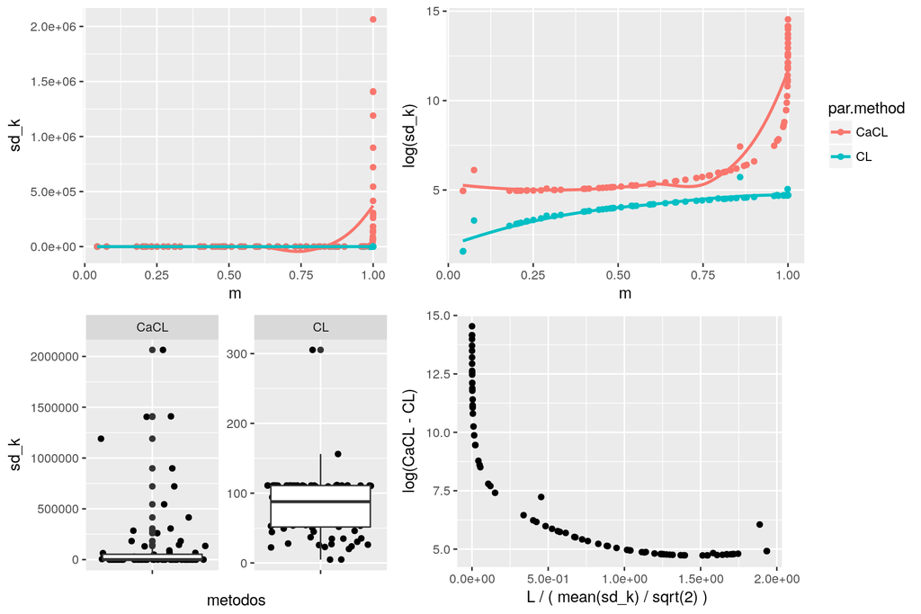

figura 1. Desvio-padrão (sd_k) estimado pelas equações 1 (método CL) e 2.b (método CaCL). 1o painel = sd_k ~ m; 2o painel: log(sd_k) ~ m; 3o - boxplot de sd_k pelos métodos (título do gráfico); 4o painel: log da diferença entre os métodos e a razão entre o lado da amostra (L) e a distância média de dispersão (mean(sd_k)/sqrt(2)). mean(sd_k) é a média dos sd_k obtidos pelos dois métodos, a divição por sqrt(2) é para transformar no parâmetro escalar da distribuição de Laplace.

-Segundo a figura 1 de Chisholm & Lichstein 2009 a equação 1 deve fazer boas aproximações quando a relação entre L/d >= 100. -O 4o painel mostra que a condição para que a equação 1 faça boas aproximações não é observada, uma vez que L/d varia em [0;2] -O maior valor de sd_k pelo método CL ~ 300 metros, enquanto do método CaCL ~ 2e6 (valor sem realismo biológico)

#### sd -> m

Agora vamos avaliar a conversão de parâmetros sd_k da simulação coalescente para o respectivo m do modelo de campo médio.

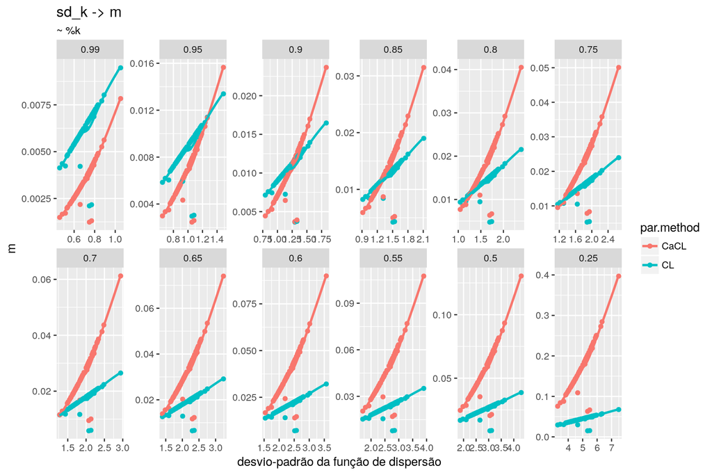

figura 2. m ~ sd_k + %k + método de calculo. em x = desvio padrão da função de dispersão (sd_k), y = m; os paineis estão divididos pelas respectivas porcentagens de propágulos que permanecem até $l_{cel}$ metros da árvore progenitora.

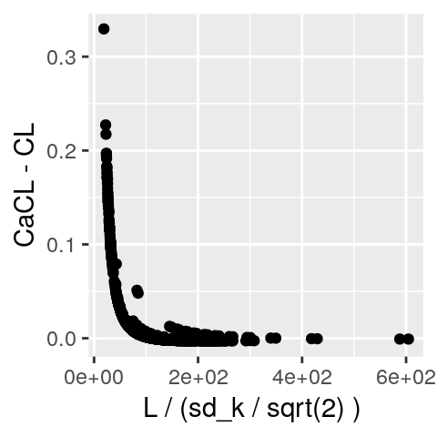

figura 3. difença no valor calculado pelos dois métodos e a razão L / (sd_k / sqrt(2) )

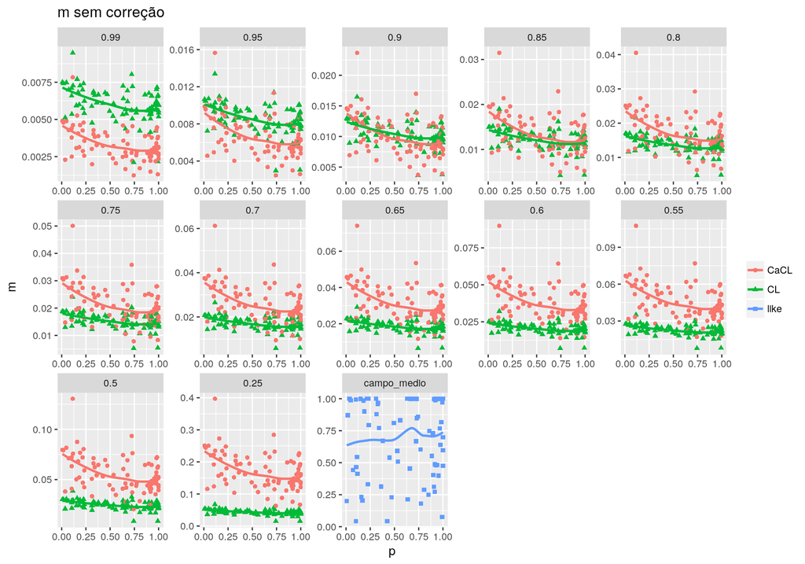

Figura 4A. m ~ p + (~kernel_percentil)

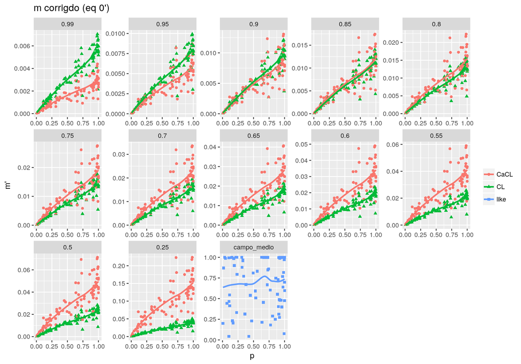

Figura 4B. m’ ~ p + (~kernel_percentil)

### Theta

Utilizamos apenas um método para converter $\theta$ e U, a definição apresentada em Hubbell (2001): $\theta = 2 J_{M}U$. Consideramos que $J_{M} = A_{paisagem} DA p$.

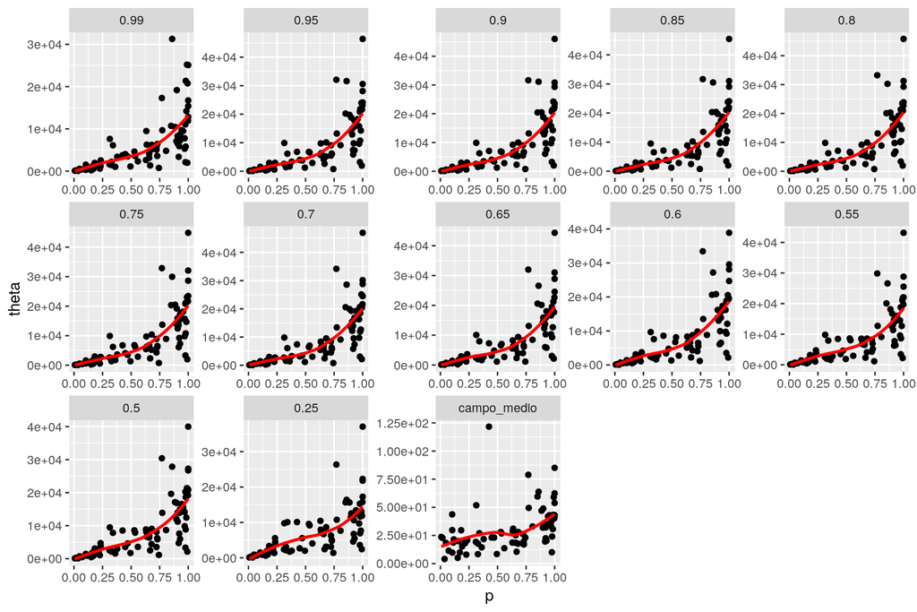

figura 5. $\theta$ ~ p + (~kernel_percentil). Cada painel corresponde ao percentil de propágulos que permanece até $l_{cel}$ metros da planta progenitora. O último painel ‘campo_medio’ corresponde ao $\theta$ obtido pelo ajuste da formula de Etienne (2005) às SADs observadas.

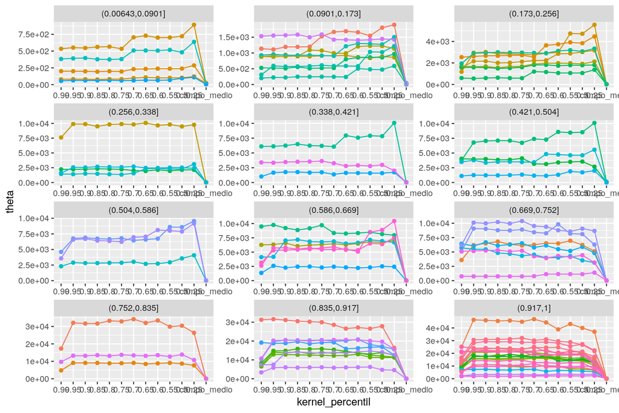

figura 6. $\theta$ ~ kernel_percentil + (~p_class). p_class = cut(p,12). Os pontos e linhas estão coloridos pelo Site.

### U

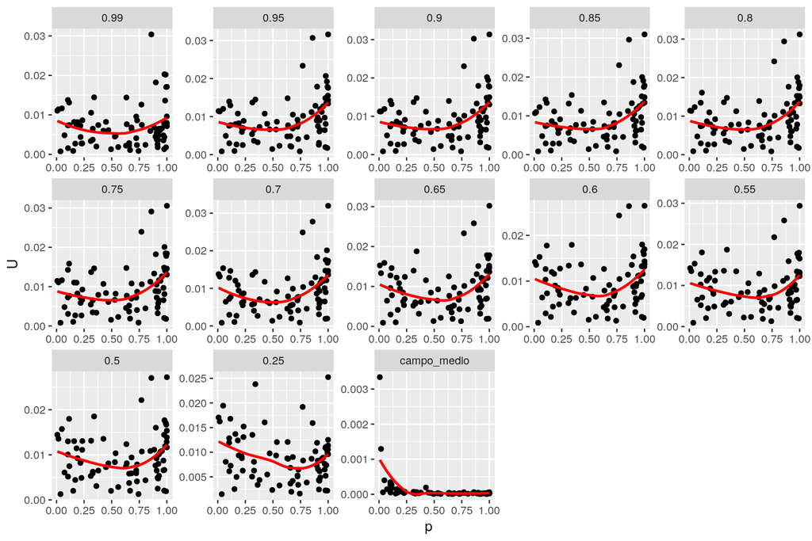

figura 7. U ~ p + (~kernel_percentil)

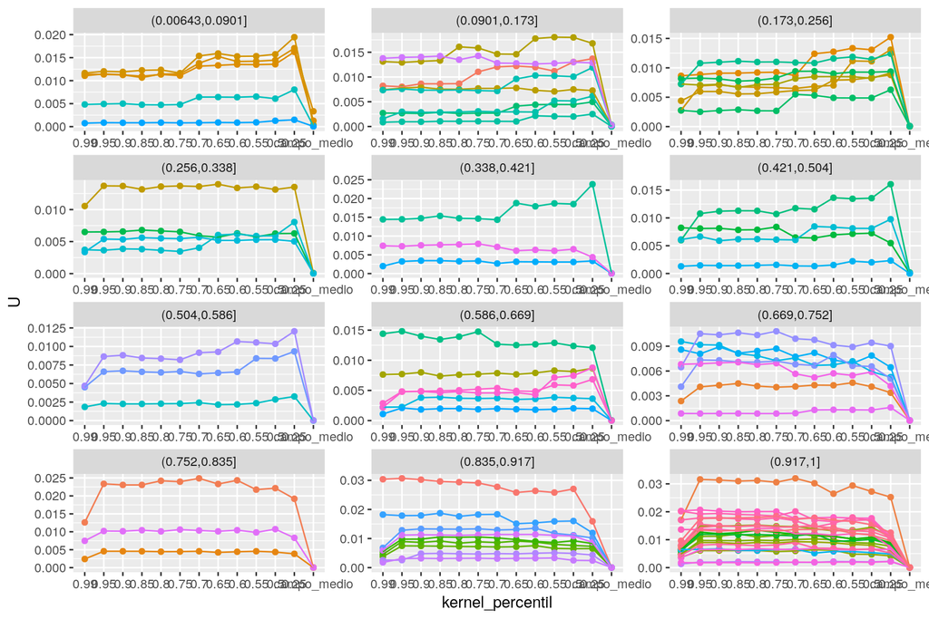

Figura 8. U ~ kernel_percentil + (~p_class); p_class = cut(p,12). Os pontos e linhas estão coloridos pelo Site.

### Chuva de Propágulos

A chuva de propágulos pode ser entendida como o produto da fecundidade e função de dispersão (Clark et al. 1999). Por conta do pressuposto da equivalência funcional todos os indivíduos produzem o mesmo número de propágulos por unidade de tempo (Hubbell 2001) e, portanto, podemos simular cenários de limitação à dispersão em função da porcentagem de propágulos que permace até determinada distância da planta progenitora. Dessa maneira, não precisamos definir a dispersão em termos de distância per se mas em termos de porcentagem de indivíduos que permanecem na área imediata da planta progenitora. Para isso é necessário estabelecer uma distância padrão da planta progenitora e estimar ou definir a porcentagem de indivíduos que se mantêm até esta distância padrão. Como distância padronizamos $l_{cel}$, assim, cada paisagem possui uma distância padrão que depende da densidade observada de indivíduos naquela paisagem. Podemos estimar qual a porcentagem de propágulos até a distância padrão que um determinado sd gera, partindo de um m (eqn 2); ou podemos informar a priori quais as porcentagens de interesse e estimar o sd necessário para gerar tais porcentagens. Na simulação coalescente, utilizamos 12 valores de porcentagem para simular os cenários de limitação à dispersão: 99 %, 95 %, 90 %, 85 %, 80 %, 75 %, 70 %, 65 %, 60 %, 55 %, 50 %, 25 %.

Na primeira sessão estimamos o desvio-padrão da função de dispersão(sd_k) a partir do parâmetro m, estimado por verossimilhança, do modelo de campo médio. Com os valores de sd_k estimados podemos calcular a respectiva chuva de propágulos. Antes de executar essa tarefa vamos observar os valores de sd_k estimados para o modelo de espaço explícito e aqueles calculados a partir de m do campo médio pelos dois métodos de conversão:

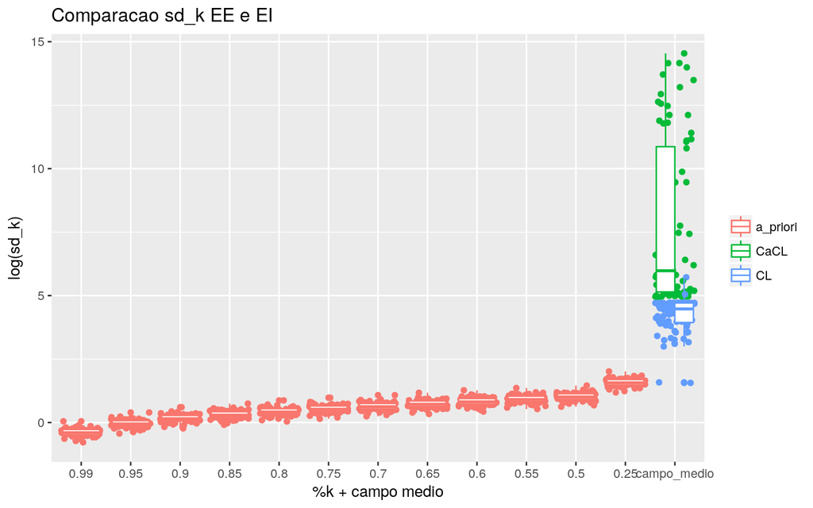

figura 9. Boxplot log(sd_k) ~ (%k + campo medio)

```r
# funcoes
f_k_perc <- function(sigma, density, npoints = 1e+05) {
    # metríca da simulacao e distancia de referencia
    d_ind_MA <- 100/sqrt(density)
    # relacao entre sd e o parametro escalar da distribuicao Laplace
    b_laplace <- sigma/sqrt(2)
    # sorteios de duas distribuicoes identicas Laplace em eixos ortogonais
    X_laplace <- d_ind_MA * round(rlaplace(npoints, s = b_laplace)/d_ind_MA)
    Y_laplace <- d_ind_MA * round(rlaplace(npoints, s = b_laplace)/d_ind_MA)
    # calculando a distancia dos pontos ate a origem
    dist_laplace <- sqrt(X_laplace^2 + Y_laplace^2)
    # Percemtil
    percentil <- length(dist_laplace[dist_laplace <= d_ind_MA])/length(dist_laplace)
    return(percentil)
}
f_percentil.kernel <- function(i, df_ = df_k_perc) {
    kernel_percentil <- f_k_perc(sigma = df_[i, "par.value"], density = df_[i,
        "DA"])
    return(kernel_percentil)
}
# armazenando
df_k_perc$k_perc <- sapply(1:nrow(df_k_perc), f_percentil.kernel)
```

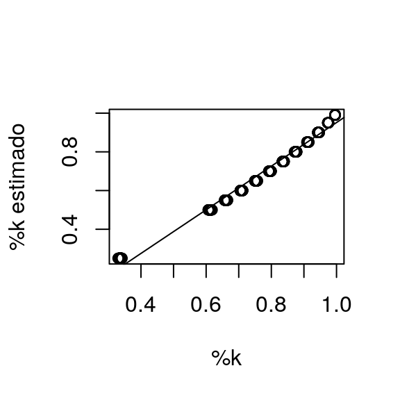

```
##
## Call:
## lm(formula = k_perc0 ~ k_perc, data = .)
##
## Residuals:
##      Min       1Q   Median       3Q      Max
## -0.02813 -0.01985 -0.01182  0.01665  0.05425
##
## Coefficients:
##              Estimate Std. Error t value Pr(>|t|)
## (Intercept) -0.175878   0.003617  -48.62   <2e-16 ***
## k_perc       1.127331   0.004500  250.54   <2e-16 ***
## ---
## Signif. codes:  0 '***' 0.001 '**' 0.01 '*' 0.05 '.' 0.1 ' ' 1
##
## Residual standard error: 0.02501 on 958 degrees of freedom
## Multiple R-squared:  0.985,  Adjusted R-squared:  0.985
## F-statistic: 6.277e+04 on 1 and 958 DF,  p-value: < 2.2e-16
```

Figura 10. Percentil de propágulos informados a priori (eixo x) e calculados pela função f_k_perc (chunk de código anterior). A linha corresponde ao modelo linear ajustado aos dados: $R^2 = 0.985$, $\alpha = -0.175$ e $\beta = 1.127$.

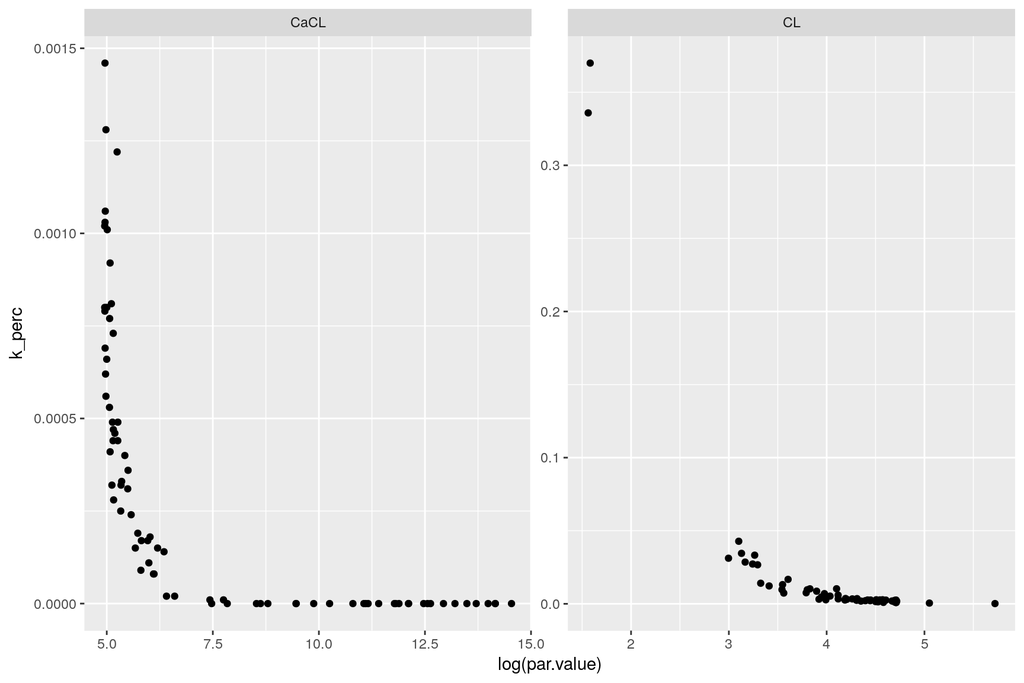